# Danish Kings Homework for week 10

Laura Bundgaard Jørgensen

2025-03-05

[output not shown]

[output cut: 150 more lines]

The task here is to load your Danish Monarchs csv into R using the `tidyverse` toolkit, calculate and explore the kings’ duration of reign with pipes `%>%` in `dplyr` and plot it over time.

## Load the kings

Make sure to first create an `.Rproj` workspace with a `data/` folder where you place either your own dataset or the provided `kings.csv` dataset.

1. Look at the dataset that are you loading and check what its columns are separated by? (hint: open it in plain text editor to see)

List what is the

separator: comma

2. Create a `kings` object in R with the different functions below and inspect the different outputs.
- `read.csv()`
- `read_csv()`
- `read.csv2()`
- `read_csv2()`

```r
# FILL IN THE CODE BELOW and review the outputs
kings1 <- read.csv("data/kings.csv")
glimpse(kings1)
```

```
## Rows: 54
## Columns: 11
## $ Name       <chr> "Gorm den Gamle", "Harald 1. Blåtand", "Toke_Gormsen", "Sve…
## $ House      <chr> "Gorm", "Gorm", "Gorm", "Gorm", "Gorm", "Gorm", "Gorm", "Fa…
## $ Start_year <chr> "936", "NULL", "985", "NULL", "1014", "1018", "1035", "1042…
## $ End_year   <chr> "958", "NULL", "986", "NULL", "1018", "1035", "1042", "1047…
## $ Birth_year <chr> "908", "936", "NULL", "NULL", "963", "NULL", "995", "1018",…
## $ Death_year <chr> "958", "985", "986", "1014", "NULL", "1035", "1042", "1047"…
## $ Gender     <chr> "M", "M ", "M ", "M ", "M ", "M ", "M ", "M ", "M ", "M ", …
## $ Dynasty    <chr> "Jellingdynastiet", "Jellingdynastiet", "Jellingdynastiet",…
## $ Source     <chr> "https://da.wikipedia.org/wiki/Gorm_den_Gamle", "https://da…
## $ BirthDMY   <chr> "908", "936", "", "17/04/963", "994", "995", "1018", "1024"…
## $ DeathDMY   <chr> "958", "987", "", "03/02/1014", "1018", "12/11/1035", "08/0…
```

```r
head(kings1)
```

```
##                Name House Start_year End_year Birth_year Death_year Gender
## 1    Gorm den Gamle  Gorm        936      958        908        958      M
## 2 Harald 1. Blåtand  Gorm       NULL     NULL        936        985     M
## 3      Toke_Gormsen  Gorm        985      986       NULL        986     M
## 4  Svend 1. Tveskæg  Gorm       NULL     NULL       NULL       1014     M
## 5         Harald 2.  Gorm       1014     1018        963       NULL     M
## 6 Knud 1. den Store  Gorm       1018     1035       NULL       1035     M
##            Dynasty                                            Source  BirthDMY
## 1 Jellingdynastiet      https://da.wikipedia.org/wiki/Gorm_den_Gamle       908
## 2 Jellingdynastiet https://da.wikipedia.org/wiki/Harald_Bl%C3%A5tand       936
## 3 Jellingdynastiet        https://da.wikipedia.org/wiki/Toke_Gormsen
## 4 Jellingdynastiet  https://da.wikipedia.org/wiki/Svend_Tvesk%C3%A6g 17/04/963
## 5 Jellingdynastiet           https://da.wikipedia.org/wiki/Harald_2.       994
## 6 Jellingdynastiet      https://da.wikipedia.org/wiki/Knud_den_Store       995
##     DeathDMY
## 1        958
## 2        987
## 3
## 4 03/02/1014
## 5       1018
## 6 12/11/1035
```

```r
kings_min_1 <- read_csv2("data/danskekongerkomma.csv")
```

```
## ℹ Using "','" as decimal and "'.'" as grouping mark. Use `read_delim()` for more control.
```

```
## ──────────────────────────────────────────────────────── Delimiter: ";" chr
## (8): navn, Født, Kilde_født, Død, Kilde_død, Kilde_StartReg., SlutReg., ... dbl
## (1): StartReg. lgl (1): ...8
```

```r
glimpse(kings_min_1)
```

```
## Rows: 57
## Columns: 10
## $ navn            <chr> "Gorm_den_gamle", "Harald_1_Blåtand", "Svend_1_Tveskæg…
## $ Født            <chr> "908-918", "930", "963", "944", "995", "1020", "1024",…
## $ Kilde_født      <chr> "https://lex.dk/Gorm_den_Gamle?gad_source=1&gclid=CjwK…
## $ Død             <chr> "958", "987", "1014", "1018", "1035", "1042", "1047", …
## $ Kilde_død       <chr> "https://natmus.dk/historisk-viden/temaer/kongeraekken…
## $ StartReg.       <dbl> NA, 958, 987, 1014, 1018, 1035, 1042, 1047, 1074, 1080…
## $ Kilde_StartReg. <chr> "Kongerækken", "Harald Blåtand, ca. 958-987", "Svend T…
## $ ...8            <lgl> NA, NA, NA, NA, NA, NA, NA, NA, NA, NA, NA, NA, NA, NA…
## $ SlutReg.        <chr> "958", "987", "1014", "1018", "1035", "1042", "1047", …
## $ Kilde_SlutReg.  <chr> "Kongerækken", "Kongerækken", "Kongerækken", "Kongeræk…
```

```r
kings_min_1$SlutReg. <- as.numeric(kings_min_1$SlutReg.)
glimpse(kings_min_1)
```

```
## Rows: 57
## Columns: 10
## $ navn            <chr> "Gorm_den_gamle", "Harald_1_Blåtand", "Svend_1_Tveskæg…
## $ Født            <chr> "908-918", "930", "963", "944", "995", "1020", "1024",…
## $ Kilde_født      <chr> "https://lex.dk/Gorm_den_Gamle?gad_source=1&gclid=CjwK…
## $ Død             <chr> "958", "987", "1014", "1018", "1035", "1042", "1047", …
## $ Kilde_død       <chr> "https://natmus.dk/historisk-viden/temaer/kongeraekken…
## $ StartReg.       <dbl> NA, 958, 987, 1014, 1018, 1035, 1042, 1047, 1074, 1080…
## $ Kilde_StartReg. <chr> "Kongerækken", "Harald Blåtand, ca. 958-987", "Svend T…
## $ ...8            <lgl> NA, NA, NA, NA, NA, NA, NA, NA, NA, NA, NA, NA, NA, NA…
## $ SlutReg.        <dbl> 958, 987, 1014, 1018, 1035, 1042, 1047, 1074, 1080, 10…
## $ Kilde_SlutReg.  <chr> "Kongerækken", "Kongerækken", "Kongerækken", "Kongeræk…
```

```r
kings2 <- read_csv("data/kings.csv")
glimpse(kings2)
```

```
## Rows: 54
## Columns: 11
## $ Name       <chr> "Gorm den Gamle", "Harald 1. Blåtand", "Toke_Gormsen", "Sve…
## $ House      <chr> "Gorm", "Gorm", "Gorm", "Gorm", "Gorm", "Gorm", "Gorm", "Fa…
## $ Start_year <chr> "936", "NULL", "985", "NULL", "1014", "1018", "1035", "1042…
## $ End_year   <chr> "958", "NULL", "986", "NULL", "1018", "1035", "1042", "1047…
## $ Birth_year <chr> "908", "936", "NULL", "NULL", "963", "NULL", "995", "1018",…
## $ Death_year <chr> "958", "985", "986", "1014", "NULL", "1035", "1042", "1047"…
## $ Gender     <chr> "M", "M", "M", "M", "M", "M", "M", "M", "M", "M", "M", "M",…
## $ Dynasty    <chr> "Jellingdynastiet", "Jellingdynastiet", "Jellingdynastiet",…
## $ Source     <chr> "https://da.wikipedia.org/wiki/Gorm_den_Gamle", "https://da…
## $ BirthDMY   <chr> "908", "936", NA, "17/04/963", "994", "995", "1018", "1024"…
## $ DeathDMY   <chr> "958", "987", NA, "03/02/1014", "1018", "12/11/1035", "08/0…
```

```r
head(kings2)
```

```
## # A tibble: 6 × 11
##   Name     House Start_year End_year Birth_year Death_year Gender Dynasty Source
##   <chr>    <chr> <chr>      <chr>    <chr>      <chr>      <chr>  <chr>   <chr>
## 1 Gorm de… Gorm  936        958      908        958        M      Jellin… https…
## 2 Harald … Gorm  NULL       NULL     936        985        M      Jellin… https…
## 3 Toke_Go… Gorm  985        986      NULL       986        M      Jellin… https…
## 4 Svend 1… Gorm  NULL       NULL     NULL       1014       M      Jellin… https…
## 5 Harald … Gorm  1014       1018     963        NULL       M      Jellin… https…
## 6 Knud 1.… Gorm  1018       1035     NULL       1035       M      Jellin… https…
## # ℹ 2 more variables: BirthDMY <chr>, DeathDMY <chr>
```

```r
kings3 <- read.csv2("data/kings.csv")
glimpse(kings3)
```

```
## Rows: 56
## Columns: 1
## $ Name.House.Start_year.End_year.Birth_year.Death_year.Gender.Dynasty.Source.BirthDMY.DeathDMY <chr> …
```

```r
head(kings3)
```

```
##                                          Name.House.Start_year.End_year.Birth_year.Death_year.Gender.Dynasty.Source.BirthDMY.DeathDMY
## 1                         Gorm den Gamle,Gorm,936,958,908,958,M,Jellingdynastiet,https://da.wikipedia.org/wiki/Gorm_den_Gamle,908,958
## 2              Harald 1. Blåtand,Gorm,NULL,NULL,936,985,M ,Jellingdynastiet,https://da.wikipedia.org/wiki/Harald_Bl%C3%A5tand,936,987
## 3                                 Toke_Gormsen,Gorm,985,986,NULL,986,M ,Jellingdynastiet,https://da.wikipedia.org/wiki/Toke_Gormsen,,
## 4 Svend 1. Tveskæg,Gorm,NULL,NULL,NULL,1014,M ,Jellingdynastiet,https://da.wikipedia.org/wiki/Svend_Tvesk%C3%A6g,17/04/963,03/02/1014
## 5                              Harald 2.,Gorm,1014,1018,963,NULL,M ,Jellingdynastiet,https://da.wikipedia.org/wiki/Harald_2.,994,1018
## 6          Knud 1. den Store,Gorm,1018,1035,NULL,1035,M ,Jellingdynastiet,https://da.wikipedia.org/wiki/Knud_den_Store,995,12/11/1035
```

```r
kings4 <- read_csv2( "data/kings.csv")
```

```
## ℹ Using "','" as decimal and "'.'" as grouping mark. Use `read_delim()` for more control.
```

```r
glimpse(kings4)
```

```
## Rows: 54
## Columns: 1
## $ `Name,House,Start_year,End_year,Birth_year,Death_year,Gender,Dynasty,Source,BirthDMY,DeathDMY` <chr> …
```

```r
head(kings4)
```

```
## # A tibble: 6 × 1
##   Name,House,Start_year,End_year,Birth_year,Death_year,Gender,Dynasty,Source,B…¹
##   <chr>
## 1 Gorm den Gamle,Gorm,936,958,908,958,M,Jellingdynastiet,https://da.wikipedia.o…
## 2 Harald 1. Blåtand,Gorm,NULL,NULL,936,985,M ,Jellingdynastiet,https://da.wikip…
## 3 Toke_Gormsen,Gorm,985,986,NULL,986,M ,Jellingdynastiet,https://da.wikipedia.o…
## 4 Svend 1. Tveskæg,Gorm,NULL,NULL,NULL,1014,M ,Jellingdynastiet,https://da.wiki…
## 5 Harald 2.,Gorm,1014,1018,963,NULL,M ,Jellingdynastiet,https://da.wikipedia.or…
## 6 Knud 1. den Store,Gorm,1018,1035,NULL,1035,M ,Jellingdynastiet,https://da.wik…
## # ℹ abbreviated name:
## #   ¹`Name,House,Start_year,End_year,Birth_year,Death_year,Gender,Dynasty,Source,BirthDMY,DeathDMY`
```

Answer: 1. Which of these functions is a `tidyverse` function? Read data with it below into a `kings` object

Tidyverse is kings2 and kings4 which is downloaded into R. Kings1 and Kings3 are the original R

2. What is the result of running `class()` on the `kings` object created with a tidyverse function.

When running class on kings 2 and kings 4 it shows:[1] “spec_tbl_df” “tbl_df” “tbl” “data.frame” and [1] “spec_tbl_df” “tbl_df” “tbl” “data.frame” which describes a tibble.

3. How many columns does the object have when created with these different functions? the kings2 have 11 columns the kings4 have 1 column
4. Show the dataset so that we can see how R interprets each column

```r
# COMPLETE THE BLANKS BELOW WITH YOUR CODE, then turn the 'eval' flag in this chunk to TRUE.


kings2 <- read_csv("data/kings.csv")
class(kings2)
```

```
## [1] "spec_tbl_df" "tbl_df"      "tbl"         "data.frame"
```

```r
class(kings4)
```

```
## [1] "spec_tbl_df" "tbl_df"      "tbl"         "data.frame"
```

```r
ncol(kings2)
```

```
## [1] 11
```

```r
ncol(kings4)
```

```
## [1] 1
```

```r
glimpse(kings2)
```

```
## Rows: 54
## Columns: 11
## $ Name       <chr> "Gorm den Gamle", "Harald 1. Blåtand", "Toke_Gormsen", "Sve…
## $ House      <chr> "Gorm", "Gorm", "Gorm", "Gorm", "Gorm", "Gorm", "Gorm", "Fa…
## $ Start_year <chr> "936", "NULL", "985", "NULL", "1014", "1018", "1035", "1042…
## $ End_year   <chr> "958", "NULL", "986", "NULL", "1018", "1035", "1042", "1047…
## $ Birth_year <chr> "908", "936", "NULL", "NULL", "963", "NULL", "995", "1018",…
## $ Death_year <chr> "958", "985", "986", "1014", "NULL", "1035", "1042", "1047"…
## $ Gender     <chr> "M", "M", "M", "M", "M", "M", "M", "M", "M", "M", "M", "M",…
## $ Dynasty    <chr> "Jellingdynastiet", "Jellingdynastiet", "Jellingdynastiet",…
## $ Source     <chr> "https://da.wikipedia.org/wiki/Gorm_den_Gamle", "https://da…
## $ BirthDMY   <chr> "908", "936", NA, "17/04/963", "994", "995", "1018", "1024"…
## $ DeathDMY   <chr> "958", "987", NA, "03/02/1014", "1018", "12/11/1035", "08/0…
```

```r
glimpse(kings4)
```

```
## Rows: 54
## Columns: 1
## $ `Name,House,Start_year,End_year,Birth_year,Death_year,Gender,Dynasty,Source,BirthDMY,DeathDMY` <chr> …
```

## Calculate the duration of reign for all the kings in your table

You can calculate the duration of reign in years with `mutate` function by subtracting the equivalents of your `startReign` from `endReign` columns and writing the result to a new column called `duration`. But first you need to check a few things:

- Is your data messy? Fix it before re-importing to R
- Do your start and end of reign columns contain NAs? Choose the right strategy to deal with them: `na.omit()`, `na.rm=TRUE`, `!is.na()`

Create a new column called `duration` in the kings dataset, utilizing the `mutate()` function from tidyverse. Check with your group to brainstorm the options.

```r
# YOUR CODE

kings2$End_year <- as.numeric(kings2$End_year)
kings2$Start_year <- as.numeric(kings2$Start_year)
kings_duration <- kings2 %>%
  mutate(duration= End_year - Start_year) %>%
  na.omit(duration)

glimpse(kings_duration)
```

```
## Rows: 49
## Columns: 12
## $ Name       <chr> "Gorm den Gamle", "Harald 2.", "Knud 1. den Store", "Hardek…
## $ House      <chr> "Gorm", "Gorm", "Gorm", "Gorm", "Fairhair", "Estridsen", "E…
## $ Start_year <dbl> 936, 1014, 1018, 1035, 1042, 1074, 1080, 1086, 1095, 1104, …
## $ End_year   <dbl> 958, 1018, 1035, 1042, 1047, 1080, 1086, 1095, 1103, 1134, …
## $ Birth_year <chr> "908", "963", "NULL", "995", "1018", "1019", "1041", "1043"…
## $ Death_year <chr> "958", "NULL", "1035", "1042", "1047", "1080", "1086", "109…
## $ Gender     <chr> "M", "M", "M", "M", "M", "M", "M", "M", "M", "M", "M", "M",…
## $ Dynasty    <chr> "Jellingdynastiet", "Jellingdynastiet", "Jellingdynastiet",…
## $ Source     <chr> "https://da.wikipedia.org/wiki/Gorm_den_Gamle", "https://da…
## $ BirthDMY   <chr> "908", "994", "995", "1018", "1024", "1041", "1043", "1050"…
## $ DeathDMY   <chr> "958", "1018", "12/11/1035", "08/06/1042", "25/10/1047", "1…
## $ duration   <dbl> 22, 4, 17, 7, 5, 6, 6, 9, 8, 30, 3, 9, 25, 20, 39, 9, 2, 7,…
```

## Calculate the average duration of reign for all rulers

Do you remember how to calculate an average on a vector object? If not, review the last two lessons and remember that a column is basically a vector. So you need to subset your `kings` dataset to the `duration` column. If you subset it as a vector you can calculate average on it with `mean()` base-R function. If you subset it as a tibble, you can calculate average on it with `summarize()` tidyverse function. Try both ways!

the summarize funtion didn’t work, so we used mean with the base-Rfuntion, and got an average on 19,9 year

- You first need to know how to select the relevant `duration` column. What are your options?
- Is your selected `duration` column a tibble or a vector? The `mean()` function can only be run on a vector. The `summarize()` function works on a tibble.
- Are you getting an error that there are characters in your column? Coerce your data to numbers with `as.numeric()`.
- Remember to handle NAs: `mean(X, na.rm=TRUE)`

```r
# YOUR CODE

mean(kings_duration$duration, na.rm = TRUE)
```

```
## [1] 19.97959
```

```r
#summarize(kings_duration,["duration"])
```

## How many and which kings enjoyed a longer-than-average duration of reign?

You have calculated the average duration above. Use it now to `filter()` the `duration` column in `kings` dataset. Display the result and also count the resulting rows with `count()`

```r
# YOUR CODE

duration_above_average <- kings_duration %>%
  filter(duration>20)

count(duration_above_average)
```

```
## # A tibble: 1 × 1
##       n
##   <int>
## 1    22
```

```r
glimpse(duration_above_average)
```

```
## Rows: 22
## Columns: 12
## $ Name       <chr> "Gorm den Gamle", "Niels", "Valdemar 1. den Store", "Valdem…
## $ House      <chr> "Gorm", "Estridsen", "Estridsen", "Estridsen", "Estridsen",…
## $ Start_year <dbl> 936, 1104, 1157, 1202, 1259, 1286, 1340, 1396, 1448, 1482, …
## $ End_year   <dbl> 958, 1134, 1182, 1241, 1286, 1319, 1375, 1439, 1481, 1513, …
## $ Birth_year <chr> "908", "1055", "1131", "1170", "1249", "1274", "1320", "138…
## $ Death_year <chr> "958", "1134", "1182", "1241", "1286", "1319", "1375", "145…
## $ Gender     <chr> "M", "M", "M", "M", "M", "M", "M", "M", "M", "M", "M", "M",…
## $ Dynasty    <chr> "Jellingdynastiet", "Jellingdynastiet", "Jellingdynastiet",…
## $ Source     <chr> "https://da.wikipedia.org/wiki/Gorm_den_Gamle", "https://da…
## $ BirthDMY   <chr> "908", "1134", "14/01/1131", "05/1170", "1249", "1274", "13…
## $ DeathDMY   <chr> "958", "25/06/1134", "12/05/1182", "28/03/1241", "22/10/128…
## $ duration   <dbl> 22, 30, 25, 39, 27, 33, 35, 43, 33, 31, 23, 29, 60, 22, 29,…
```

## How many days did the three longest-ruling monarchs rule?

- Sort kings by reign `duration` in the descending order. Select the three longest-ruling monarchs with the `slice()` function
- Use `mutate()` to create `Days` column where you calculate the total number of days they ruled
- BONUS: consider the transition year (with 366 days) in your calculation!

```r
# YOUR CODE

duration_descending <- kings_duration %>%
  arrange(desc(duration))

glimpse(duration_descending)
```

```
## Rows: 49
## Columns: 12
## $ Name       <chr> "Christian 4.", "Margrete 2.", "Erik 7. af Pommern", "Chris…
## $ House      <chr> "Oldenburg", "Schleswig-Holstein-Sonderburg-Glücksborg", "P…
## $ Start_year <dbl> 1588, 1972, 1396, 1863, 1766, 1202, 1340, 1912, 1286, 1448,…
## $ End_year   <dbl> 1648, 2023, 1439, 1906, 1808, 1241, 1375, 1947, 1319, 1481,…
## $ Birth_year <chr> "1577", "1940", "1382", "1818", "1749", "1170", "1320", "18…
## $ Death_year <chr> "1648", "NULL", "1459", "1906", "1808", "1241", "1375", "19…
## $ Gender     <chr> "M", "F", "M", "M", "M", "M", "M", "M", "M", "M", "M", "M",…
## $ Dynasty    <chr> "Oldenborg", "Glücksborg", "Jellingdynastiet", "Glücksborg"…
## $ Source     <chr> "https://da.wikipedia.org/wiki/Christian_4.", "https://da.w…
## $ BirthDMY   <chr> "12/04/1577", "16/1/1940", "1382", "08/04/1818", "29/01/174…
## $ DeathDMY   <chr> "28/02/1648", "14/1/2024", "24/09/1459", "29/1/1906", "13/0…
## $ duration   <dbl> 60, 51, 43, 43, 42, 39, 35, 35, 33, 33, 31, 31, 31, 30, 29,…
```

```r
longest_ruler <- duration_descending %>%
  slice(c(1,2,3))

glimpse(longest_ruler)
```

```
## Rows: 3
## Columns: 12
## $ Name       <chr> "Christian 4.", "Margrete 2.", "Erik 7. af Pommern"
## $ House      <chr> "Oldenburg", "Schleswig-Holstein-Sonderburg-Glücksborg", "P…
## $ Start_year <dbl> 1588, 1972, 1396
## $ End_year   <dbl> 1648, 2023, 1439
## $ Birth_year <chr> "1577", "1940", "1382"
## $ Death_year <chr> "1648", "NULL", "1459"
## $ Gender     <chr> "M", "F", "M"
## $ Dynasty    <chr> "Oldenborg", "Glücksborg", "Jellingdynastiet"
## $ Source     <chr> "https://da.wikipedia.org/wiki/Christian_4.", "https://da.w…
## $ BirthDMY   <chr> "12/04/1577", "16/1/1940", "1382"
## $ DeathDMY   <chr> "28/02/1648", "14/1/2024", "24/09/1459"
## $ duration   <dbl> 60, 51, 43
```

```r
longest_ruler %>%
  mutate(days=duration*366)
```

```
## # A tibble: 3 × 13
##   Name     House Start_year End_year Birth_year Death_year Gender Dynasty Source
##   <chr>    <chr>      <dbl>    <dbl> <chr>      <chr>      <chr>  <chr>   <chr>
## 1 Christi… Olde…       1588     1648 1577       1648       M      Oldenb… https…
## 2 Margret… Schl…       1972     2023 1940       NULL       F      Glücks… https…
## 3 Erik 7.… Pome…       1396     1439 1382       1459       M      Jellin… https…
## # ℹ 4 more variables: BirthDMY <chr>, DeathDMY <chr>, duration <dbl>,
## #   days <dbl>
```

## Challenge: Plot the kings’ duration of reign through time

What is the long-term trend in the duration of reign among Danish monarchs? How does it relate to the historical violence trends ?

- Try to plot the duration of reign column in `ggplot` with `geom_point()` and `geom_smooth()`
- In order to peg the duration (which is between 1-99) somewhere to the x axis with individual centuries, I recommend creating a new column `midyear` by adding to `startYear` the product of `endYear` minus the `startYear` divided by two (`startYear + (endYear-startYear)/2`).
- Now you can plot the kings dataset, plotting `midyear` along the x axis and `duration` along y axis
- BONUS: add a title, nice axis labels to the plot and make the theme B&W and font bigger to make it nice and legible!

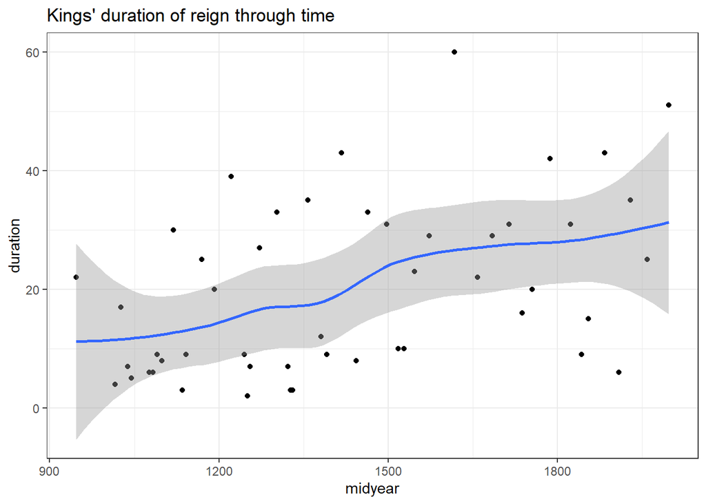

```r
# YOUR CODE

kings_duration_and_midyear <- kings_duration %>%
  mutate(midyear= Start_year+duration/2)

kings_duration_and_midyear %>%
  ggplot(aes(x=midyear, y=duration))+geom_point()+geom_smooth()+theme_bw()+ggtitle("Kings' duration of reign through time")
```

And to submit this rmarkdown, knit it into html. But first, clean up the code chunks, adjust the date, rename the author and change the `eval=FALSE` flag to `eval=TRUE` so your script actually generates an output. Well done!